# Road Collision Severity Analysis — Great Britain 2023

Yani BOUDJEMA

2026-04-03

# 1 Introduction

This report presents a comprehensive analysis of road collision data recorded across Great Britain in 2023, sourced from the Department for Transport (DfT). The dataset encompasses **104,258 reported collisions**, each described by 44 variables covering environmental conditions, road infrastructure, geographic information, and collision outcomes.

The primary objective of this analysis is twofold:

1. **Exploratory Data Analysis (EDA):** Identify the key environmental and infrastructural factors associated with collision severity, through both univariate and bivariate investigation of the most informative variables.
2. **Data Preprocessing:** Prepare the dataset for downstream predictive modelling by addressing missing values, encoding categorical variables, and normalising continuous features.

The target variable is `collision_severity`, a three-level ordinal outcome:

- `1` → **Fatal** — results in at least one death
- `2` → **Serious** — involves at least one serious injury
- `3` → **Slight** — involves minor injuries only

# 2 Environment Setup

## 2.1 Required Libraries

```r
library(tidyverse)
library(janitor)
library(fastDummies)
```

## 2.2 Data Import & Initial Cleaning

```r
data <- read.csv("Data/dft_collisions_2023.csv")

# Recode -1 as NA (DfT convention for "unknown / not applicable")
data <- data %>%
  mutate(across(where(is.numeric), ~ na_if(., -1)))

# Convert the target variable to an ordered factor
data$collision_severity <- factor(
  data$collision_severity,
  levels  = c(1, 2, 3),
  labels  = c("Fatal", "Serious", "Slight"),
  ordered = TRUE
)
```

The DfT dataset uses the sentinel value `-1` throughout to indicate unknown or inapplicable observations. These are recoded to `NA` at import to ensure correct handling by all downstream functions.

# 3 Exploratory Data Analysis

## 3.1 Dataset Overview

```r
glimpse(data)
```

```
## Rows: 104,258
## Columns: 44
## $ collision_index                                  <chr> "2023170L30453", "202…
## $ collision_year                                   <int> 2023, 2023, 2023, 202…
## $ collision_ref_no                                 <chr> "170L30453", "1112930…
## $ location_easting_osgr                            <int> 456584, 434218, 43061…
## $ location_northing_osgr                           <int> 522423, 514041, 51426…
## $ longitude                                        <dbl> -1.125794, -1.472891,…
## $ latitude                                         <dbl> 54.59383, 54.52052, 5…
## $ police_force                                     <int> 17, 11, 11, 7, 7, 4, …
## $ collision_severity                               <ord> Slight, Slight, Serio…
## $ number_of_vehicles                               <int> 3, 1, 2, 2, 2, 2, 2, …
## $ number_of_casualties                             <int> 1, 1, 1, 1, 1, 1, 1, …
## $ date                                             <chr> "21/05/2023", "28/03/…
## $ day_of_week                                      <int> 1, 3, 1, 4, 2, 4, 6, …
```

[output cut: 31 more lines]

The dataset contains **104258 observations** and **44 variables**, representing every road collision reported to the police in Great Britain during 2023.

The variable types break down as follows:

- **Numeric (continuous):** geographic coordinates (`longitude`, `latitude`), `speed_limit`
- **Numeric (discrete):** `number_of_vehicles`, `number_of_casualties`
- **Categorical (encoded as integer):** severity, road type, lighting, weather, surface conditions, and several others
- **Character / identifier:** `collision_index`, `date`, `time`, `lsoa_of_accident_location`

## 3.2 Target Variable: Collision Severity

```r
# Frequency table
severity_tbl <- data %>%
  count(collision_severity) %>%
  mutate(pct = round(100 * n / sum(n), 2))

severity_tbl
```

```
##   collision_severity     n   pct
## 1              Fatal  1522  1.46
## 2            Serious 23438 22.48
## 3             Slight 79298 76.06
```

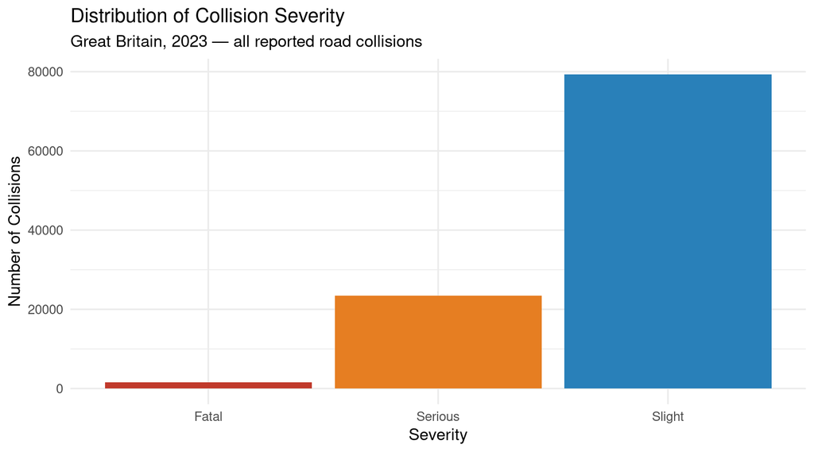

```r
# Visual
ggplot(data, aes(x = collision_severity, fill = collision_severity)) +
  geom_bar(show.legend = FALSE) +
  scale_fill_manual(values = c("Fatal" = "#c0392b", "Serious" = "#e67e22", "Slight" = "#2980b9")) +
  labs(
    title    = "Distribution of Collision Severity",
    subtitle = "Great Britain, 2023 — all reported road collisions",
    x        = "Severity",
    y        = "Number of Collisions"
  ) +
  theme_minimal(base_size = 13)
```

The dataset is **heavily imbalanced across severity classes**:

- **Slight** collisions represent **76.1%** of all reported events
- **Serious** collisions account for **22.5%**
- **Fatal** collisions are rare, at just **1.5%**

This severe class imbalance has important implications for modelling: standard accuracy metrics will be misleading, and resampling strategies or class-weighted loss functions will be necessary in any predictive pipeline.

## 3.3 Data Quality Assessment

```r
summary(data %>% select(collision_severity, number_of_vehicles, number_of_casualties,
                         speed_limit, light_conditions, weather_conditions,
                         road_surface_conditions, urban_or_rural_area))
```

```
##  collision_severity number_of_vehicles number_of_casualties  speed_limit
##  Fatal  : 1522      Min.   : 1.000     Min.   : 1.000       Min.   :20.00
##  Serious:23438      1st Qu.: 1.000     1st Qu.: 1.000       1st Qu.:30.00
##  Slight :79298      Median : 2.000     Median : 1.000       Median :30.00
##                     Mean   : 1.821     Mean   : 1.275       Mean   :35.87
##                     3rd Qu.: 2.000     3rd Qu.: 1.000       3rd Qu.:40.00
##                     Max.   :17.000     Max.   :70.000       Max.   :70.00
##
##  light_conditions weather_conditions road_surface_conditions
##  Min.   :1.000    Min.   :1.00       Min.   :1.000
##  1st Qu.:1.000    1st Qu.:1.00       1st Qu.:1.000
##  Median :1.000    Median :1.00       Median :1.000
##  Mean   :2.026    Mean   :1.69       Mean   :1.441
##  3rd Qu.:4.000    3rd Qu.:1.00       3rd Qu.:2.000
##  Max.   :7.000    Max.   :9.00       Max.   :9.000
##                                      NA's   :1064
##  urban_or_rural_area
##  Min.   :1.000
##  1st Qu.:1.000
##  Median :1.000
##  Mean   :1.326
##  3rd Qu.:2.000
##  Max.   :3.000
##  NA's   :8
```

```r
# Count NAs per column (only show columns with missing data)
na_summary <- data %>%
  summarise(across(everything(), ~ sum(is.na(.)))) %>%
  pivot_longer(everything(), names_to = "variable", values_to = "n_missing") %>%
  filter(n_missing > 0) %>%
  mutate(pct_missing = round(100 * n_missing / nrow(data), 1)) %>%
  arrange(desc(n_missing))

na_summary
```

```
## # A tibble: 20 × 3
##    variable                                         n_missing pct_missing
##    <chr>                                                <int>       <dbl>
##  1 local_authority_district                            104258       100
##  2 enhanced_severity_collision                          48241        46.3
##  3 junction_control                                     43795        42
##  4 second_road_number                                   43046        41.3
##  5 trunk_road_flag                                       7487         7.2
##  6 carriageway_hazards_historic                          3127         3
##  7 special_conditions_at_site                            3116         3
##  8 carriageway_hazards                                   3086         3
##  9 pedestrian_crossing_human_control_historic            2789         2.7
## 10 pedestrian_crossing_physical_facilities_historic      2783         2.7
## 11 pedestrian_crossing                                   2768         2.7
## 12 junction_detail                                       2398         2.3
## 13 road_surface_conditions                               1064         1
## 14 second_road_class                                       84         0.1
## 15 location_easting_osgr                                   12         0
## 16 location_northing_osgr                                  12         0
## 17 longitude                                               12         0
## 18 latitude                                                12         0
## 19 urban_or_rural_area                                      8         0
## 20 junction_detail_historic                                 1         0
```

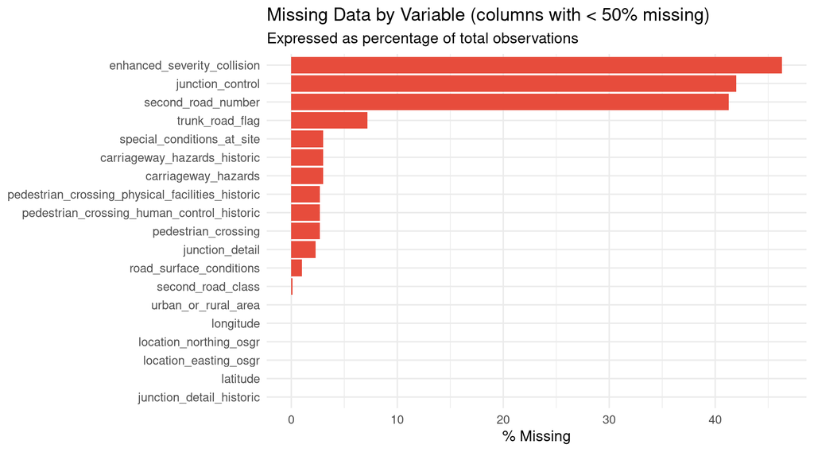

```r
ggplot(na_summary %>% filter(pct_missing < 50),
       aes(x = reorder(variable, pct_missing), y = pct_missing)) +
  geom_col(fill = "#e74c3c") +
  coord_flip() +
  labs(
    title    = "Missing Data by Variable (columns with < 50% missing)",
    subtitle = "Expressed as percentage of total observations",
    x        = NULL,
    y        = "% Missing"
  ) +
  theme_minimal(base_size = 12)
```

**Key observations:**

- `enhanced_severity_collision` is missing for 46.3% of records and will be excluded from analysis
- `junction_control` and `second_road_number` have ~42% missing, reflecting cases where no junction was involved — these are structurally missing, not random
- Operational variables (`road_surface_conditions`, `weather_conditions`, `carriageway_hazards`) have missing rates below 5%, manageable with imputation

# 4 Helper Functions

```r
# ── Reusable plotting utilities ───────────────────────────────────────────────

# Coloured bar chart for a categorical variable
plot_bar <- function(df, var, title, fill_col = "steelblue") {
  ggplot(df, aes(x = factor(.data[[var]]))) +
    geom_bar(fill = fill_col) +
    labs(title = title, x = var, y = "Count") +
    theme_minimal(base_size = 12)
}

# Stacked proportion bar: categorical variable vs. severity
plot_severity_prop <- function(df, var, title, x_label = var) {
  ggplot(df, aes(x = factor(.data[[var]]), fill = collision_severity)) +
    geom_bar(position = "fill") +
    scale_fill_manual(
      values = c("Fatal" = "#c0392b", "Serious" = "#e67e22", "Slight" = "#2980b9"),
      name   = "Severity"
    ) +
    scale_y_continuous(labels = scales::percent_format()) +
    labs(title = title, x = x_label, y = "Proportion") +
    theme_minimal(base_size = 12)
}

# Histogram for a continuous variable
plot_histogram <- function(df, var, title, bins = 30) {
  ggplot(df, aes(x = .data[[var]])) +
    geom_histogram(bins = bins, fill = "steelblue", colour = "white") +
    labs(title = title, x = var, y = "Count") +
    theme_minimal(base_size = 12)
}

# Boxplot: continuous variable by severity
plot_boxplot_severity <- function(df, var, title, y_label = var, log_scale = FALSE) {
  p <- ggplot(df, aes(x = collision_severity, y = .data[[var]],
                      fill = collision_severity)) +
    geom_boxplot(show.legend = FALSE, outlier.alpha = 0.2) +
    scale_fill_manual(values = c("Fatal" = "#c0392b", "Serious" = "#e67e22",
                                 "Slight" = "#2980b9")) +
    labs(title = title, x = "Severity", y = y_label) +
    theme_minimal(base_size = 12)
  if (log_scale) p <- p + scale_y_log10()
  p
}

# ── IQR-based outlier detection ───────────────────────────────────────────────
outliers_iqr <- function(x) {
  Q1  <- quantile(x, 0.25, na.rm = TRUE)
  Q3  <- quantile(x, 0.75, na.rm = TRUE)
  IQR_val <- Q3 - Q1
  x[x < (Q1 - 1.5 * IQR_val) | x > (Q3 + 1.5 * IQR_val)]
}

# ── Descriptive statistics ────────────────────────────────────────────────────
desc_stats <- function(df, var) {
  x <- df[[var]]
  cat(sprintf("  N (non-missing) : %d\n",  sum(!is.na(x))))
  cat(sprintf("  Mean            : %.3f\n", mean(x, na.rm = TRUE)))
  cat(sprintf("  Median          : %.3f\n", median(x, na.rm = TRUE)))
  cat(sprintf("  SD              : %.3f\n", sd(x, na.rm = TRUE)))
  cat(sprintf("  Min / Max       : %.1f / %.1f\n", min(x, na.rm = TRUE), max(x, na.rm = TRUE)))
}
```

# 5 Analysis of Key Risk Variables

The variables selected for in-depth analysis are those with the strongest theoretical link to collision severity, consistent with the road safety literature: speed, lighting, weather, road surface, area type, number of vehicles, and number of casualties.

## 5.1 Speed Limit (`speed_limit`)

Speed is consistently identified as a primary determinant of collision severity: higher speeds translate directly into greater kinetic energy at impact.

### 5.1.1 Univariate Analysis

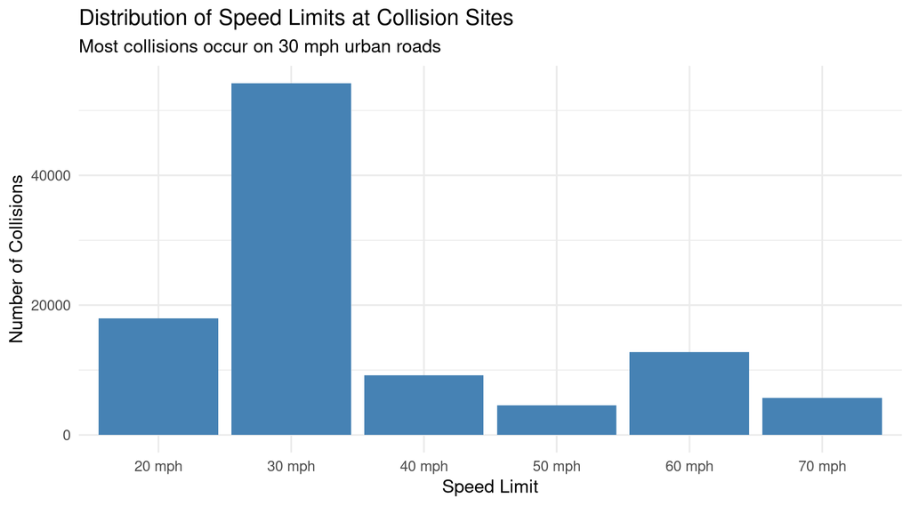

```r
# Recode speed_limit as labelled factor for plotting
data_plot <- data %>%
  mutate(speed_lim_f = factor(speed_limit,
                               levels = c(20, 30, 40, 50, 60, 70),
                               labels = c("20 mph", "30 mph", "40 mph",
                                          "50 mph", "60 mph", "70 mph")))

ggplot(data_plot %>% filter(!is.na(speed_lim_f)), aes(x = speed_lim_f)) +
  geom_bar(fill = "steelblue") +
  labs(
    title    = "Distribution of Speed Limits at Collision Sites",
    subtitle = "Most collisions occur on 30 mph urban roads",
    x        = "Speed Limit",
    y        = "Number of Collisions"
  ) +
  theme_minimal(base_size = 13)
```

```r
desc_stats(data, "speed_limit")
```

```
##   N (non-missing) : 104258
##   Mean            : 35.874
##   Median          : 30.000
##   SD              : 14.349
##   Min / Max       : 20.0 / 70.0
```

The distribution is markedly bimodal: the **30 mph** zone accounts for more than half of all collisions (54,177), reflecting the dominance of urban road networks in terms of traffic volume and exposure. The **60 mph** category corresponds primarily to single-carriageway rural roads, which are disproportionately dangerous per vehicle-kilometre travelled.

### 5.1.2 Bivariate Analysis

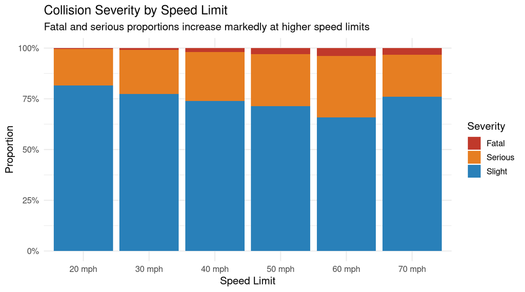

```r
data_plot %>%
  filter(!is.na(speed_lim_f), !is.na(collision_severity)) %>%
  ggplot(aes(x = speed_lim_f, fill = collision_severity)) +
  geom_bar(position = "fill") +
  scale_fill_manual(
    values = c("Fatal" = "#c0392b", "Serious" = "#e67e22", "Slight" = "#2980b9"),
    name   = "Severity"
  ) +
  scale_y_continuous(labels = scales::percent_format()) +
  labs(
    title    = "Collision Severity by Speed Limit",
    subtitle = "Fatal and serious proportions increase markedly at higher speed limits",
    x        = "Speed Limit",
    y        = "Proportion"
  ) +
  theme_minimal(base_size = 13)
```

## 5.2 Light Conditions (`light_conditions`)

Reduced visibility is a well-established risk factor in road safety. This variable captures whether the collision occurred in daylight or various levels of artificial/low-light conditions.

### 5.2.1 Variable Encoding

| Code | Description |
| --- | --- |
| 1 | Daylight |
| 4 | Darkness — lights lit |
| 5 | Darkness — lights unlit |
| 6 | Darkness — no lighting |
| 7 | Darkness — lighting unknown |

### 5.2.2 Univariate Analysis

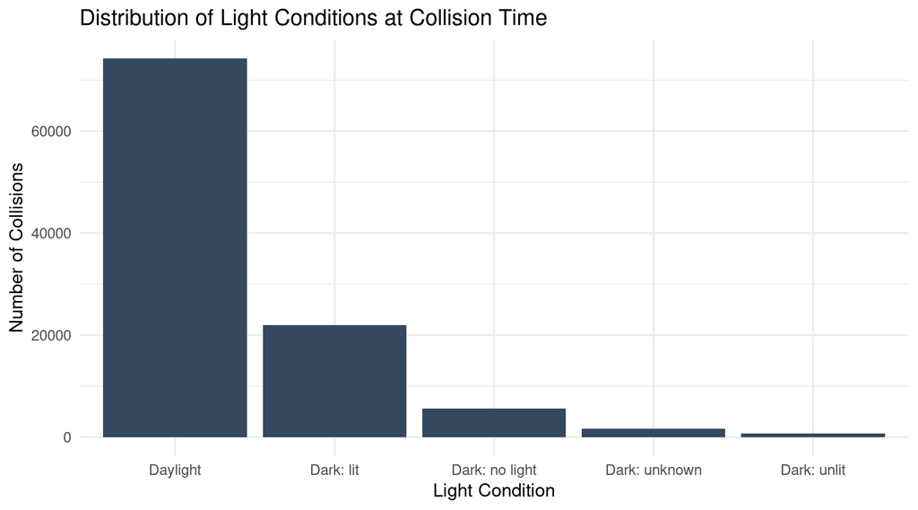

```r
light_labels <- c("1" = "Daylight", "4" = "Dark: lit", "5" = "Dark: unlit",
                   "6" = "Dark: no light", "7" = "Dark: unknown")

data %>%
  filter(!is.na(light_conditions)) %>%
  mutate(light_f = recode(factor(light_conditions), !!!light_labels)) %>%
  ggplot(aes(x = fct_infreq(light_f))) +
  geom_bar(fill = "#34495e") +
  labs(
    title    = "Distribution of Light Conditions at Collision Time",
    x        = "Light Condition",
    y        = "Number of Collisions"
  ) +
  theme_minimal(base_size = 13)
```

The vast majority of collisions (**71.2%**) occur in daylight, which reflects higher traffic exposure during the day. However, the absolute frequency should not obscure the per-exposure risk: nighttime collisions are disproportionately severe.

### 5.2.3 Bivariate Analysis

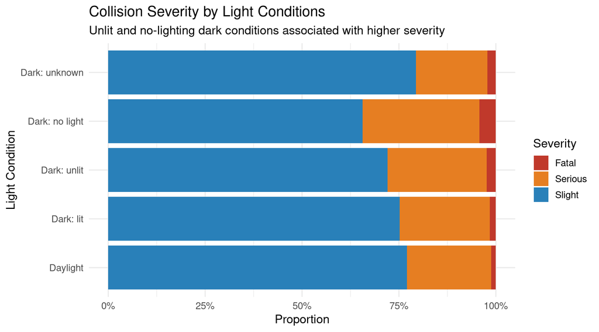

```r
data %>%
  filter(!is.na(light_conditions), !is.na(collision_severity)) %>%
  mutate(light_f = recode(factor(light_conditions), !!!light_labels)) %>%
  ggplot(aes(x = light_f, fill = collision_severity)) +
  geom_bar(position = "fill") +
  scale_fill_manual(
    values = c("Fatal" = "#c0392b", "Serious" = "#e67e22", "Slight" = "#2980b9"),
    name   = "Severity"
  ) +
  scale_y_continuous(labels = scales::percent_format()) +
  labs(
    title    = "Collision Severity by Light Conditions",
    subtitle = "Unlit and no-lighting dark conditions associated with higher severity",
    x        = "Light Condition",
    y        = "Proportion"
  ) +
  coord_flip() +
  theme_minimal(base_size = 13)
```

Collisions occurring in **darkness without any street lighting** have a markedly higher proportion of fatal and serious outcomes compared to daylight collisions. Conversely, collisions on roads with functional street lighting at night show severity profiles closer to daytime collisions, underlining the protective effect of infrastructure.